# R Notebook

```r
rm(list = ls(all = TRUE))
setwd('c:/Users/cyma9/Dropbox/SocialNetwork/Assignments/Assignment5/')
require(sna)
require(network)
require(ergm)
require(data.table)
require(igraph)
raw = fread('startup_rounds_and_participants.csv')
raw = unique(raw)
```

```r
user_id = unique(raw$participant_id[raw$participant_type == 'User'])
startup_id = union(unique(raw$startup_id),unique(raw$participant_id[raw$participant_type == 'Startup']))
id = seq(1,length(user_id)+length(startup_id),1)
nodes = cbind(id, c(user_id,startup_id))
colnames(nodes)[2] = 'former_id'
edges1 = merge(nodes, raw, by.x = 'former_id',by.y = 'startup_id')
colnames(edges1)[1] = 'former_s_id'
colnames(edges1)[2] = 's_id'
edges2 = merge(nodes, edges1, by.x = 'former_id',by.y = 'participant_id')
colnames(edges2)[1] = 'former_p_id'
colnames(edges2)[2] = 'p_id'
net = network(edges2[,c('s_id','p_id')],directed = TRUE)
net %n% "round" = edges2[,5]
net %n% "type"  = as.numeric(factor(edges2$participant_type))
net %n% "traction" = edges2[,8]
raw_startup = raw[raw$participant_type == 'Startup',]
id = seq(1,length(startup_id),1)
nodes_s = cbind(id, startup_id)
colnames(nodes_s)[2] = 'former_id'
edges1_s = merge(nodes_s, raw_startup, by.x = 'former_id',by.y = 'startup_id')
colnames(edges1_s)[1] = 'former_s_id'
colnames(edges1_s)[2] = 's_id'
edges2_s = merge(nodes_s, edges1_s, by.x = 'former_id',by.y = 'participant_id')
colnames(edges2_s)[1] = 'former_p_id'
colnames(edges2_s)[2] = 'p_id'
net_startup = network(edges2_s[,c('s_id','p_id')],directed = TRUE)
net_startup %n% "round" = edges2_s[,5]
net_startup %n% "type"  = as.numeric(factor(edges2_s$participant_type))
net_startup %n% "traction" = edges2_s[,8]
```

# Question 1

```r
m1=ergm(net ~ edges + mutual, burnin=15000,MCMCsamplesize=30000,verbose=FALSE)
```

```
Starting maximum likelihood estimation via MCMLE:
Iteration 1 of at most 20:
Optimizing with step length 1.
The log-likelihood improved by 0.001157.
Step length converged once. Increasing MCMC sample size.
Iteration 2 of at most 20:
Optimizing with step length 1.
The log-likelihood improved by 0.003344.
Step length converged twice. Stopping.
Evaluating log-likelihood at the estimate. Using 20 bridges: 1 2 3 4 5 6 7 8 9 10 11 12 13 14 15 16 17 18 19 20 .
This model was fit using MCMC.  To examine model diagnostics and check for degeneracy, use the mcmc.diagnostics() function.
```

```r
m1_startup = ergm(net_startup ~ edges + mutual, burnin=15000,MCMCsamplesize=30000,verbose=FALSE)
```

```
Starting maximum likelihood estimation via MCMLE:
Iteration 1 of at most 20:
Optimizing with step length 1.
The log-likelihood improved by 0.0005101.
Step length converged once. Increasing MCMC sample size.
Iteration 2 of at most 20:
Optimizing with step length 1.
The log-likelihood improved by 0.0007478.
Step length converged twice. Stopping.
Evaluating log-likelihood at the estimate. Using 20 bridges: 1 2 3 4 5 6 7 8 9 10 11 12 13 14 15 16 17 18 19 20 .
This model was fit using MCMC.  To examine model diagnostics and check for degeneracy, use the mcmc.diagnostics() function.
```

```r
summary(m1)
```

```
==========================
Summary of model fit
==========================

Formula:   net ~ edges + mutual

Iterations:  2 out of 20

Monte Carlo MLE Results:
       Estimate Std. Error MCMC % p-value
edges  -3.96414    0.04267      0  <1e-04 ***
mutual  0.35920    0.36502      0   0.325
---
Signif. codes:  0 ‘***’ 0.001 ‘**’ 0.01 ‘*’ 0.05 ‘.’ 0.1 ‘ ’ 1

     Null Deviance: 44170  on 31862  degrees of freedom
 Residual Deviance:  5947  on 31860  degrees of freedom

AIC: 5951    BIC: 5967    (Smaller is better.)
```

```r
summary(m1_startup)
```

```
==========================
Summary of model fit
==========================

Formula:   net_startup ~ edges + mutual

Iterations:  2 out of 20

Monte Carlo MLE Results:
       Estimate Std. Error MCMC % p-value
edges   -3.5086     0.0627      0  <1e-04 ***
mutual   0.6583     0.3729      0  0.0775 .
---
Signif. codes:  0 ‘***’ 0.001 ‘**’ 0.01 ‘*’ 0.05 ‘.’ 0.1 ‘ ’ 1

     Null Deviance: 13724  on 9900  degrees of freedom
 Residual Deviance:  2651  on 9898  degrees of freedom

AIC: 2655    BIC: 2670    (Smaller is better.)
```

# Question 2

Use the network information and an ERGM model to predict whether startups are more likely to have larger fundraising rounds (i.e., the “has as a participant” relationship is more likely to exist) if they also participate in more funding rounds. You can run the model on the entire network or just relationships between startups. In either case, include an edges intercept as well as a mutuality covariate in the model.

```r
idegree = sna::degree(net_startup,cmode = 'indegree')
net_startup %v% "idegree" = idegree
m2_startup = ergm(net_startup ~ edges + mutual + nodecov('idegree'), burnin=15000,MCMCsamplesize=30000,verbose=FALSE)
```

```
Starting maximum likelihood estimation via MCMLE:
Iteration 1 of at most 20:
Optimizing with step length 1.
The log-likelihood improved by 0.01183.
Step length converged once. Increasing MCMC sample size.
Iteration 2 of at most 20:
Optimizing with step length 1.
The log-likelihood improved by 0.002695.
Step length converged twice. Stopping.
Evaluating log-likelihood at the estimate. Using 20 bridges: 1 2 3 4 5 6 7 8 9 10 11 12 13 14 15 16 17 18 19 20 .
This model was fit using MCMC.  To examine model diagnostics and check for degeneracy, use the mcmc.diagnostics() function.
```

```r
summary(m2_startup)
```

```
==========================
Summary of model fit
==========================

Formula:   net_startup ~ edges + mutual + nodecov("idegree")

Iterations:  2 out of 20

Monte Carlo MLE Results:
                Estimate Std. Error MCMC % p-value
edges           -4.97440    0.18093      0  <1e-04 ***
mutual           0.34355    0.37977      0   0.366
nodecov.idegree  0.21974    0.02312      0  <1e-04 ***
---
Signif. codes:  0 ‘***’ 0.001 ‘**’ 0.01 ‘*’ 0.05 ‘.’ 0.1 ‘ ’ 1

     Null Deviance: 13724  on 9900  degrees of freedom
 Residual Deviance:  2558  on 9897  degrees of freedom

AIC: 2564    BIC: 2586    (Smaller is better.)
```

# Question 3

Use the network information provided and an ERGM model to predict whether an investor is more or less likely to participate in a startup’s round if it has participated in in one of its rounds in the previous year. Include an edges intercept as well as a mutuality covariate in the model.

```r
edges2$year = as.numeric(substring(edges2$round_record_date,1,4))
edges_in = edges2[edges2$participant_type == 'User',]
network12 = matrix(0,179,80)
for (i in c(1:nrow(edges_in)))
{
  if (edges_in$year[i] == 2012)
    network12[edges_in$s_id[i], edges_in$p_id[i]] = 1
}
edges_in2 = edges_in[edges_in$year == 2013|edges_in$year==2014,]
previous = rep(0,nrow(edges_in2))
for (i in c(1:nrow(edges_in2)))
{
  if (edges_in2$participant_type[i] == 'User'){
      if (network12[edges_in2$s_id[i],edges_in2$p_id[i]] == 1)
        previous[i] = 1}
}
edges_in3 = cbind(edges_in2, previous)
edges_in3$p_id = as.factor(edges_in3$p_id)
edges_in3$s_id = as.factor(edges_in3$s_id)
net_in = network(edges_in3[,c('s_id','p_id')],directed = TRUE)
net_in %n% "previous" = edges_in3[,10]
m3= ergm(net_in ~ edges + mutual + edgecov('previous'), burnin=15000,MCMCsamplesize=30000,verbose=FALSE,control = control.ergm(seed = 8))
```

```
Observed statistic(s) mutual are at their smallest attainable values. Their coefficients will be fixed at -Inf.
Starting maximum likelihood estimation via MCMLE:
Iteration 1 of at most 20:
Optimizing with step length 1.
The log-likelihood improved by 0.3378.
Step length converged once. Increasing MCMC sample size.
Iteration 2 of at most 20:
Optimizing with step length 0.21979949872074.
The log-likelihood did not improve.
Iteration 3 of at most 20:
Optimizing with step length 1.
The log-likelihood improved by 3.887.
Step length converged once. Increasing MCMC sample size.
Iteration 4 of at most 20:
Optimizing with step length 1.
The log-likelihood improved by 0.8293.
Step length converged twice. Stopping.
Evaluating log-likelihood at the estimate. Using 20 bridges: 1 2 3 4 5 6 7 8 9 10 11 12 13 14 15 16 17 18 19 20 .
This model was fit using MCMC.  To examine model diagnostics and check for degeneracy, use the mcmc.diagnostics() function.
```

```r
summary(m3)
```

```
==========================
Summary of model fit
==========================

Formula:   net_in ~ edges + mutual + edgecov("previous")

Iterations:  4 out of 20

Monte Carlo MLE Results:
                 Estimate Std. Error MCMC % p-value
edges            -4.39304    0.07872      0  <1e-04 ***
mutual               -Inf    0.00000      0  <1e-04 ***
edgecov.previous -0.28178    0.48501      0   0.561
---
Signif. codes:  0 ‘***’ 0.001 ‘**’ 0.01 ‘*’ 0.05 ‘.’ 0.1 ‘ ’ 1

     Null Deviance: 19466  on 14042  degrees of freedom
 Residual Deviance:   NaN  on 14039  degrees of freedom

AIC: NaN    BIC: NaN    (Smaller is better.)

 Warning: The following terms have infinite coefficient estimates:
  mutual
```

# Question 4

Use the network and startup attributes and an ERGM model to predict whether a startup is more likely to have participants in its rounds that have gained similar levels of traction in the current year. Then, build a model to predcict whether a startup is more likely to have participants in its rounds that have gained similar levels of traction using a term for the current year as well as the previous year. Only consider interactions between startups in these models, and include an edges intercept as well as a mutuality covariate in both models.

The level of tractions are calculated by the absolute value of differences between tractions of startups and participated divided by the sum of them( for regularization).

```r
traction_data = rep(0,300)
traction = array(traction_data,c(100,3))
edges4_s = edges2_s
edges4_s$year = as.numeric(substring(edges4_s$round_record_date,1,4))
edges4_s = na.omit(edges4_s)
#edges2_s[is.na(edges2_s)] = 0
for (i in c(1:nrow(edges4_s)))
{
  if (traction[edges4_s$s_id[i],edges4_s$year[i]-2011] == 0)
    traction[edges4_s$s_id[i],edges4_s$year[i]-2011] = edges4_s$traction[i]
  else
    if (traction[edges4_s$s_id[i],edges4_s$year[i]-2011] != edges4_s$traction[i])
      traction[edges4_s$s_id[i],edges4_s$year[i]-2011] = traction[edges4_s$s_id[i],edges4_s$year[i]-2011] + edges4_s$traction[i]
}
for (i in c(1:nrow(edges4_s))){

  if(is.na(traction[edges4_s$s_id[i],edges4_s$year[i]-2011]))
    traction_s = 0
  else
    traction_s = traction[edges4_s$s_id[i],edges4_s$year[i]-2011]
  if(is.na(traction[edges4_s$p_id[i],edges4_s$year[i]-2011]))
    traction_p = 0
  else
    traction_p = traction[edges4_s$p_id[i],edges4_s$year[i]-2011]

  edges4_s$traction_current[i] = abs(traction_s - traction_p)/(traction_s+traction_p)
}
#edges4_s[is.na(edges4_s)] = 0
edges4_s = na.omit(edges4_s)
net4_current = network(edges4_s[,c('s_id','p_id')],directed = TRUE)
#set.edge.attribute(net4_current, "traction_current", edges4_s$traction_current)
net4_current %n% "traction_current" = edges4_s$traction_current
m4_current = ergm(net4_current ~ edges + mutual + edgecov('traction_current'),burnin=15000,MCMCsamplesize=30000,verbose=FALSE)
```

```
Starting maximum likelihood estimation via MCMLE:
Iteration 1 of at most 20:
Optimizing with step length 1.
The log-likelihood improved by 0.001286.
Step length converged once. Increasing MCMC sample size.
Iteration 2 of at most 20:
Optimizing with step length 1.
The log-likelihood improved by 0.0007141.
Step length converged twice. Stopping.
Evaluating log-likelihood at the estimate. Using 20 bridges: 1 2 3 4 5 6 7 8 9 10 11 12 13 14 15 16 17 18 19 20 .
This model was fit using MCMC.  To examine model diagnostics and check for degeneracy, use the mcmc.diagnostics() function.
```

```r
summary(m4_current)
```

```
==========================
Summary of model fit
==========================

Formula:   net4_current ~ edges + mutual + edgecov("traction_current")

Iterations:  2 out of 20

Monte Carlo MLE Results:
                         Estimate Std. Error MCMC % p-value
edges                     -3.1288     0.1910      0 < 1e-04 ***
mutual                     0.8144     0.3786      0 0.03151 *
edgecov.traction_current  -0.5666     0.2162      0 0.00877 **
---
Signif. codes:  0 ‘***’ 0.001 ‘**’ 0.01 ‘*’ 0.05 ‘.’ 0.1 ‘ ’ 1

     Null Deviance: 13724  on 9900  degrees of freedom
 Residual Deviance:  2467  on 9897  degrees of freedom

AIC: 2473    BIC: 2495    (Smaller is better.)
```

For second part, we do a subset on the whole network dataset to keep only 2013 and 2014 to build the network. But for calculating the traction, we are still going to use the whole dataset.

```r
set.seed(42)
edges4_s2 = edges2_s
edges4_s2$year = as.numeric(substring(edges4_s2$round_record_date,1,4))
edges4_s2 = edges4_s2[edges4_s2$year == 2013 | edges4_s2$year == 2014,]
for (i in c(1:nrow(edges4_s2))){

  if(is.na(traction[edges4_s2$s_id[i],edges4_s2$year[i]-2011]))
    traction_s = 0
  else
    traction_s = traction[edges4_s2$s_id[i],edges4_s2$year[i]-2011]
  if(is.na(traction[edges4_s2$p_id[i],edges4_s2$year[i]-2012]))
    traction_p = 0
  else
    traction_p = traction[edges4_s2$p_id[i],edges4_s2$year[i]-2012]

  edges4_s2$traction_both[i] = abs(traction_s - traction_p)/(traction_s+traction_p)
}
edges4_s2 = na.omit(edges4_s2)
edges4_s2$p_id = as.factor(edges4_s2$p_id)
edges4_s2$s_id = as.factor(edges4_s2$s_id)
net4_both = network(edges4_s2[,c('s_id','p_id')],directed = TRUE)
net4_both %n% "traction_both" = edges4_s2$traction_both
m4_both = ergm(net4_both ~ edges + mutual + edgecov('traction_both'),burnin=15000,MCMCsamplesize=30000,verbose=FALSE)
```

```
Starting maximum likelihood estimation via MCMLE:
Iteration 1 of at most 20:
Optimizing with step length 1.
The log-likelihood improved by 0.002038.
Step length converged once. Increasing MCMC sample size.
Iteration 2 of at most 20:
Optimizing with step length 1.
The log-likelihood improved by 0.004094.
Step length converged twice. Stopping.
Evaluating log-likelihood at the estimate. Using 20 bridges: 1 2 3 4 5 6 7 8 9 10 11 12 13 14 15 16 17 18 19 20 .
This model was fit using MCMC.  To examine model diagnostics and check for degeneracy, use the mcmc.diagnostics() function.
```

```r
summary(m4_both)
```

```
==========================
Summary of model fit
==========================

Formula:   net4_both ~ edges + mutual + edgecov("traction_both")

Iterations:  2 out of 20

Monte Carlo MLE Results:
                      Estimate Std. Error MCMC % p-value
edges                  -4.2012     0.3119      0  <1e-04 ***
mutual                 -0.4098     0.9717      0   0.673
edgecov.traction_both   0.3565     0.3458      0   0.303
---
Signif. codes:  0 ‘***’ 0.001 ‘**’ 0.01 ‘*’ 0.05 ‘.’ 0.1 ‘ ’ 1

     Null Deviance: 10134  on 7310  degrees of freedom
 Residual Deviance:  2933  on 7307  degrees of freedom

AIC: 2939    BIC: 2959    (Smaller is better.)
```

# Question5

Of the models run so far, which has the best fit to the actual network? Discuss the model fit using (1) the built-in mcmc diagnostics, (2) a simulation of the actual network using the results from the model, and (3) a goodness-of-fit analysis of the estimated model.

## Built-in mcmc diagnostics

```
Sample statistics summary:

Iterations = 16384:4209664
Thinning interval = 1024
Number of chains = 1
Sample size per chain = 4096

1. Empirical mean and standard deviation for each variable,
   plus standard error of the mean:

                    Mean     SD Naive SE Time-series SE
edges           -0.71484  17.07  0.26665        0.35999
mutual           0.09302   2.86  0.04468        0.05888
nodecov.idegree -6.54053 133.56  2.08688        3.06915

2. Quantiles for each variable:

                  2.5% 25% 50%   75% 97.5%
edges            -33.0 -12  -1 11.00    33
mutual            -5.0  -2   0  2.00     6
nodecov.idegree -263.6 -98 -10 84.25   257


Sample statistics cross-correlations:
                    edges    mutual nodecov.idegree
edges           1.0000000 0.3137929       0.9441463
mutual          0.3137929 1.0000000       0.3419930
nodecov.idegree 0.9441463 0.3419930       1.0000000

Sample statistics auto-correlation:
Chain 1
               edges       mutual nodecov.idegree
Lag 0    1.000000000  1.000000000      1.00000000
Lag 1024 0.291345980  0.246663276      0.36756811
Lag 2048 0.070993281  0.083257705      0.12925261
Lag 3072 0.029945507  0.046144180      0.05780881
Lag 4096 0.005833339  0.003826674      0.02032429
Lag 5120 0.017354263 -0.020363004      0.02189447

Sample statistics burn-in diagnostic (Geweke):
Chain 1

Fraction in 1st window = 0.1
Fraction in 2nd window = 0.5

          edges          mutual nodecov.idegree
       -0.36160         0.07075        -0.28837

Individual P-values (lower = worse):
          edges          mutual nodecov.idegree
      0.7176526       0.9435973       0.7730653
Joint P-value (lower = worse):  0.9842437 .
```

```
Package latticeExtra is not installed. Falling back on coda's default MCMC diagnostic plots.
```

[output not shown]

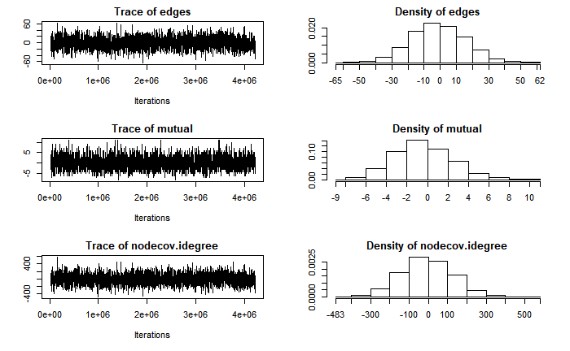

```r
mcmc2 = mcmc.diagnostics(m2_startup)
```

The m2 model got a joint p-value of 0.9842437, which should be pretty high. And in the right of the plot, all the graph show a roughly normal distribution around zero, while in the left of the plot, the MCMC sample statistics are varying randomly around the observed value so it is “mixing” well.

## simulation

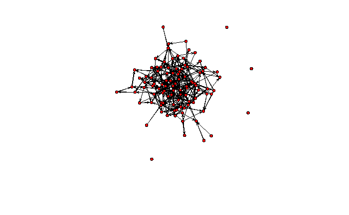

We have ploted the simulated graph. Then compare it with the original one:

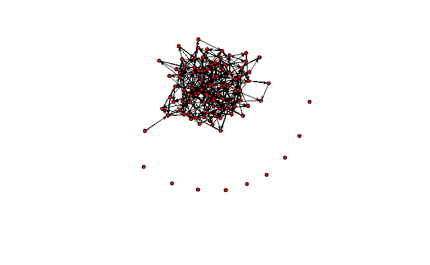

```r
plot(net_startup)
```

They look like quite similiar.

## gof plot

```r
gof2 = gof(m2_startup~model)
plot(gof2)

par(mfrow = c(2, 2))
invisible(plot(gof(m2_startup)))
```

[output not shown]

```r
require(RSiena)
```